# MSDS 7337 Homework 2

Author: Nathan Wall

Date: 5/28/2019

The notebook below works through the questions as part of the homework 2.

```python
import re
import string
import pandas as pd
import numpy as np
import seaborn as sns
import nltk
from urllib import request
from bs4 import BeautifulSoup, SoupStrainer
```

## Reading in the Data

First we grab all the book links from the main url

```python
## create a list of links to scrape
base_url = "http://www.gutenberg.org/wiki/Children's_Instructional_Books_(Bookshelf)"
response = request.urlopen(base_url)
linksToBooks = SoupStrainer('a', href=re.compile('gutenberg.org/ebooks/'))
linksToText = SoupStrainer('a', href=re.compile('.utf-8'))
book_links = []
text_links = []
for l1 in BeautifulSoup(response, parse_only=linksToBooks):
    if l1.has_attr('href'):
        book_link = ('https:'+l1['href'])
        book_links.append(book_link)
```

```python
print(len(book_links))
```

```
104
```

Then go into each of the book URLs and scape the link for the actual book text.

```python
text_links = []
for b in book_links:
    r = request.urlopen(b)
    soup = BeautifulSoup(r, 'html.parser')
    href_tags = soup.find_all(href=True, text=u'Plain Text UTF-8')
    text_links.append('https:'+href_tags[0].attrs['href'])
```

```python
print(len(text_links))
```

```
104
```

Now that we have all the links lets begin by reading that data in and processing it through an NLP pipeline. This will allow us to answer the questions defined below.

The three functions below will allow us to strip on the generic gutenberg text that is not relevant to the actual material.

```python
def remove_header(text, header):
    start_tag_location = -1
    position = -1
    content_tag_len = -1

    start_tag_location = text.find(header)

    if start_tag_location > -1:
        position = start_tag_location
        header_len = len(header)
        updated_position = start_tag_location + header_len + 1

    if position > -1:
        text = text[(updated_position):]

    return text

def remove_footer(text, footer):
    end_tag_location = -1
    position = -1

    end_tag_location = text.find(footer)

    if end_tag_location > -1:
        position = end_tag_location

    if position > -1:
        text = text[:(position - 1)]

    return text

def remove_header_footer(text, headers, footers):
    for header in headers:
        h = header.lower()
        text = remove_header(text, h)

    for footer in footers:
        f = footer.lower()
        text = remove_footer(text, f)

    return text

def remove_characters(tokens):
    pattern = re.compile('[{}]'.format(re.escape(string.punctuation)))
    filtered_tokens = filter(None, [pattern.sub('', token) for token in tokens])
    return filtered_tokens
```

Below we will go ahead and add in the stop words that we wish to filter out & set up our function for calculating lexical diversity.

```python
from nltk.corpus import stopwords
stop_words = stopwords.words('english')

def lexical_diversity(text):
    return len(set(text)) / len(text)
```

Then we will define function that will apply some of the gutenberg filtering, then tokenize and clean up some of those tokens. The final output will be the cleaned up tokens with some corresponding scores of those tokens in a dictionary.

```python
def nlp_prep(url, headers, footers):
    response = request.urlopen(url)
    html = response.read().decode('utf8')
    raw = BeautifulSoup(html, 'html.parser').get_text(strip=True).lower()

    trimmed_text = remove_header_footer(raw, headers, footers)
    tokens = nltk.word_tokenize(trimmed_text)

    cleaned_tokens = remove_characters(tokens)

    text = nltk.Text(cleaned_tokens, name = url[1])

    words = [word for word in text if word not in stop_words]

    #calculate the vocab size
    vocab = sorted(set(words))
    vocab_size = len(vocab)

    #calculate the long word vocab size
    long_vocab = sorted(set([w for w in words if len(w) > 15]))
    long_vocab_size = len(long_vocab)

    #calculate the lexical diversity
    lexical_div = lexical_diversity(words)

    return {
            "text": words,
            "vocab_size": vocab_size,
            "long_vocab_size": long_vocab_size,
            "lexical_div": lexical_div
           }
```

Now we can list the criteria for defining headers and generate a list of dictionaries from the result of of the nlp_prep() function from above.

```python
headers = ["start of project gutenberg ebook","start of project gutenberg's","start of this project gutenberg ebook", "start of the project gutenberg ebook"]
footers = ["end of project gutenberg's", "end of project gutenberg ebook", "end of this project gutenberg ebook", "end of the project gutenberg ebook"]
texts = []
for url in text_links:
    texts.append(nlp_prep(url, headers, footers))

df = pd.DataFrame(texts)
```

```python
df.info()
```

```
<class 'pandas.core.frame.DataFrame'>
RangeIndex: 104 entries, 0 to 103
Data columns (total 4 columns):
lexical_div        104 non-null float64
long_vocab_size    104 non-null int64
text               104 non-null object
vocab_size         104 non-null int64
dtypes: float64(1), int64(2), object(1)
memory usage: 3.3+ KB
```

The final output is a list of size 104 for each of the 104 links from the Guttenberg bookshelf. We can now start analyzing and interpretting this data.

## Problem 1

##### Normalized Scoring of the Vocabulary Size of Text

Before selecting a normalization scheme lets first look a the distribtution of the various vocabulary sizes, to determine is a simple max min scaler is appropriate.

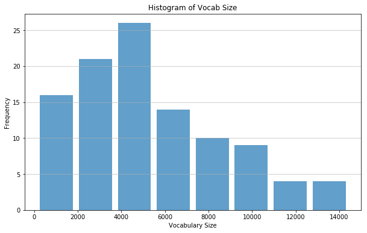

```python
import matplotlib.pyplot as plt

fig, ax = plt.subplots(figsize=(10, 6))

n, bins, patches = plt.hist(x=df.vocab_size, bins='auto', alpha=0.7, rwidth=0.85)

plt.grid(axis='y', alpha=0.75)
plt.xlabel('Vocabulary Size')
plt.ylabel('Frequency')
plt.title('Histogram of Vocab Size')
plt.show()
```

Based on the information above we will choose to simply scale our values based on the minimum and maximum values for the vocabulary size. Meaning that the lowest vocabulary size from the 100 books would now be represented by a 0 and the highest vocabulary size by a 1.

Based the histogram we see that there is in fact some skew it seems minimal enough that no transformations would be needed. Additionally we do not see any extreme outliers making this normalization technique reasonable. Also maintaining the original distribution could prove usesful when trying to measure the relative difficulty of each text, by not forcing "harder" texts closer to the mean.

```python
def minMaxScaler(var):
    var -= var.min()
    var /= var.max()
    return var
```

```python
df["vocab_size"] = minMaxScaler(df["vocab_size"])
```

```python
df["vocab_size"].describe()
```

```
count    104.000000
mean       0.359676
std        0.236273
min        0.000000
25%        0.208132
50%        0.299140
75%        0.506136
max        1.000000
Name: vocab_size, dtype: float64
```

## Problem 2

##### Create a method for normalized scoring the long-word vocabulary size of text

For simplicity the long-word scoring was done during the NLP pipeline above. The count is based on words in the books vocabulary greater than 15 alphanumeric characters long. The code used was:

```
long_vocab = sorted(set([w for w in words if len(w) > 15]))
long_vocab_size = len(long_vocab)
```

We will follow a similar path as above for determining an appropriate scale for this the long word vocabulary size as well.

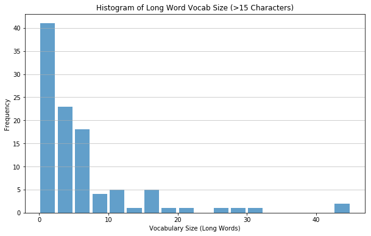

```python
import matplotlib.pyplot as plt

fig, ax = plt.subplots(figsize=(10, 6))

n, bins, patches = plt.hist(x=df.long_vocab_size, bins='auto', alpha=0.7, rwidth=0.85)

plt.grid(axis='y', alpha=0.75)
plt.xlabel('Vocabulary Size (Long Words)')
plt.ylabel('Frequency')
plt.title('Histogram of Long Word Vocab Size (>15 Characters)')
plt.show()
```

Unlike the normal vocabulary size there is a lot more skew in this data that we did not have before. Additionally the presence of ouliers in the far right tail could impact the score a simple max-min scale. Lets look at the log-transform of this data to see if this would help handle some of our concerns.

```python
df["log_long_vocab_size"] = np.log(df["long_vocab_size"]+1)
```

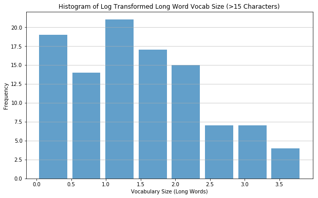

```python
import matplotlib.pyplot as plt

fig, ax = plt.subplots(figsize=(10, 6))

n, bins, patches = plt.hist(x=df.log_long_vocab_size, bins='auto', alpha=0.7, rwidth=0.85)

plt.grid(axis='y', alpha=0.75)
plt.xlabel('Vocabulary Size (Long Words)')
plt.ylabel('Frequency')
plt.title('Histogram of Log Transformed Long Word Vocab Size (>15 Characters)')
plt.show()
```

The log transform looks much more like the distribution of the vocabulary size. It appears to have handled the skew and those 2 outliers that we saw in the previous distribution. From here we can apply our min max scaler to convert the values to a 0 to 1 scale based on the log transformed values.

```python
df["log_long_vocab_size"] = minMaxScaler(df["log_long_vocab_size"])
```

```python
df["log_long_vocab_size"].describe()
```

```
count    104.000000
mean       0.376723
std        0.259339
min        0.000000
25%        0.181043
50%        0.362085
75%        0.543128
max        1.000000
Name: log_long_vocab_size, dtype: float64
```

## Problem 3

##### Text Difficulty Score:

- **Equal weighting of lexical diversity, normalized vocab score, and normalized long word vocab score**

Before scoring each text we first need to convert our lexical diversity to the same scale as the other two scores above. While we know it is already between 0 and 1 it is likely that no values reach 0 or 1. This would reduce the overall impact of the lexical diversity score and thus would not be weighted equally.

```python
df['lexical_div'] = round(minMaxScaler(df['lexical_div']),3)
```

Before creating the singular score we take a quick look at all the individual relationships between our scores.

```
array([[<matplotlib.axes._subplots.AxesSubplot object at 0x7f6b720ecf28>,
      dtype=object)
```

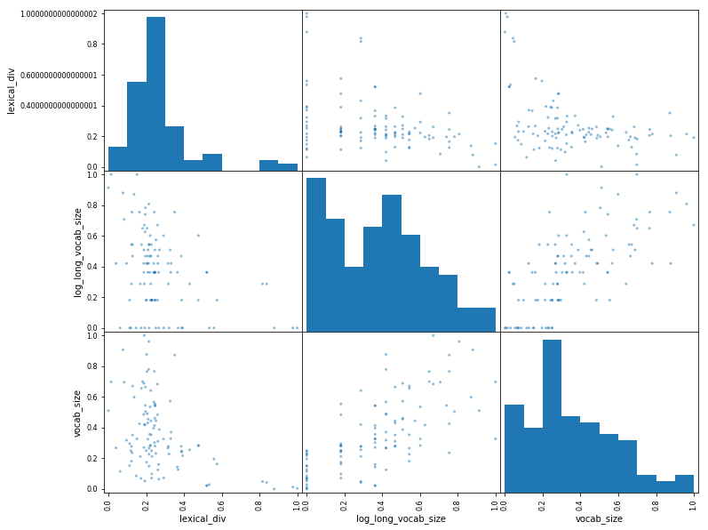

```python
scores = ["lexical_div", "log_long_vocab_size", "vocab_size"]
pd.plotting.scatter_matrix(df[scores], figsize=(12,10))
```

Unsuprisingly there is a positive linear relationship between vocab size and long vocab size. However, it is very interesting that lexical diversity has an almost negative relationship with the the other two scoring methods, with the highest lexical diversity scores falling near the the lowest values for the two vocab sizes.

We will add these three values together and see take a look at our combined scores.

```python
df['difficulty'] = df["lexical_div"]/3 + df["log_long_vocab_size"]/3 + df["vocab_size"]/3
```

```python
df = df.sort_values(by='difficulty', ascending=False)
df.head()
```

|  | lexical_div | long_vocab_size | text | vocab_size | log_long_vocab_size | difficulty |
| --- | --- | --- | --- | --- | --- | --- |
| 26 | 0.214 | 21 | [ontario, readers, produced, jacqueline, jerem... | 0.961401 | 0.807347 | 0.660916 |
| 38 | 0.351 | 17 | [first, italian, readings, etext, prepared, ch... | 0.872806 | 0.754934 | 0.659580 |
| 71 | 0.077 | 28 | [modern, history, produced, david, edwards, ch... | 0.907000 | 0.879501 | 0.621167 |
| 21 | 0.190 | 12 | [mcguffey, sixth, eclectic, reader, produced, ... | 1.000000 | 0.669937 | 0.619979 |
| 82 | 0.243 | 17 | [modern, prose, poetry, produced, online, dist... | 0.766450 | 0.754934 | 0.588128 |

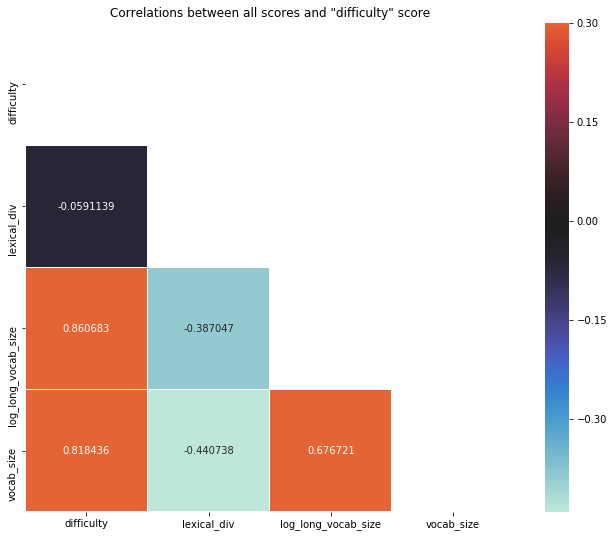

```python
# Compute the correlation matrix
corr = df[['difficulty', 'lexical_div', 'log_long_vocab_size', 'vocab_size']].corr()

# Generate a mask for the upper triangle
mask = np.zeros_like(corr, dtype=np.bool)
mask[np.triu_indices_from(mask)] = True

# Set up the matplotlib figure
f, ax = plt.subplots(figsize=(11, 9))

# Draw the heatmap with the mask and correct aspect ratio
sns.heatmap(corr, mask=mask, vmax=.3, center=0, annot=True, fmt='g',
            square=True, linewidths=.5)
plt.title('Correlations between all scores and "difficulty" score')
```

Based on the above we see that lexical diversity shares almost no correlation with our difficulty score, while both vocab size and the log transformed long vocab size have a very strong positive relationship with our score. As we have shown through prior exercises both lexical diversity and vocab size togethers are better indicator of text difficulty than vocab size alone. However, because of the strong relationship between vocab size and long vocab size we are essentially double weighting text difficulty based on it's vocabulary size.

Based on this it is difficult to feel comfortable on the reliability of the difficult score as defined. A better weighting schema could be determined through a supervised learning exercise. Where the difficulty score is labeled and the weights can be learned. However, this corpus does not contain those labels.